# Practical Machine Learning: Course Project

A. Chau

Date: 2017-04-24

### Synopsis

In this project, I examined data collected from 6 participants who performed 5 different types of barbell lifts. Only 1 of these types was a correct barbell lift (Class A). The other 4 types involved common mistakes: throwing the elbows to the front (Class B), lifting the dumbbell only halfway (Class C), lowering the dumbbell only halfway (Class D), and throwing the hips to the front (Class E). Accelerometers attached on the belt, forearm, arm, and dumbell were used to measure each barbell lift. The goal of this project was to **predict the manner (i.e., Class) in which participants did the exercise**. I attempted to solve this problem by building 3 different classification models (i.e., classification tree, gradient boosting, and random forest) and assessing their predictive accuracy on an out-of-sample data set. Lastly, the best performing model was selected and applied to the test data set.

The data analyzed in this project was part of the Weight Lifting Exercise Data Set:

Velloso, E.; Bulling, A.; Gellersen, H.; Ugulino, W.; Fuks, H. [Qualitative Activity Recognition of Weight Lifting Exercises](http://groupware.les.inf.puc-rio.br/work.jsf?p1=11201). Proceedings of 4th International Conference in Cooperation with SIGCHI (Augmented Human ’13). Stuttgart, Germany: ACM SIGCHI, 2013.

### Loading and subsetting the data

The train and test data sets were loaded.

```r
train <- read.csv("./pml-training.csv", na.strings = c("", "NA", "#DIV/0!"))
test <- read.csv("./pml-testing.csv")
```

The train data set consisted of 19622 observations and 160 variables. The test data set was only used for final evaluation purposes.

The train data set was divided into a training (75%) and validation (25%) data sets. The training data set was used to train each of the 3 models, and validation data set was used to assess the out-of-sample predictive accuracy of each model.

```r
set.seed(123)
inTrain <- createDataPartition(y = train$classe, p = 0.75, list = FALSE)
training <- train[inTrain, ]
validation <- train[-inTrain, ]
```

### Cleaning the data

After examining the data, I noticed that there were summary variables (e.g., kurtosis, skewness, average, standard deviation) that had many NA’s (e.g., 98%) and corresponded with the *new_window* and *num_window* variables. However, not every level of *num_window* had summary statistics and the number of observations varied greatly for each level. This suggested that I may not have had the complete data set and calculating summary statistics for each level *num_window* may not be appropriate. Thus, I removed variables with more than 50% NA’s from the data set.

```r
na_count <- sapply(training, function(y) sum(length(which(is.na(y)))))
training_complete <- training[, na_count < (nrow(training) * 0.5)]
```

### Predicting using classification trees

First, I built an entire classification tree, and then pruned the tree based on the recommdation to use the largest cp (complexity parameter) value associated with the smallest tree that is within 1 standard deviation of the tree with the smallest error. The resulting tree is displayed below.

[figure not shown]

```r
# pruned classification tree
treeModel <- rpart(classe ~ ., data = training_complete[,8:60], method = "class",
                   control = rpart.control(xval = 10, cp = 2.4e-04))

# predict validation class
treePredVal <- predict(treeModel, newdata = validation, type = "class")

# plot tree
rpart.plot(treeModel)
```

The prediction accuracy of this model on the validation data set was **92.27%**. Although this out-of-sample accuracy is pretty high, I might be able to still improve with other models. Classification trees are generally known for their easier interpretability, while other models, such as gradient boosting and random forest, are known for their better predictive accuracy.

### Predicting using gradient boosting

Next, I built a gradient boosting model. I also used cross-validation method with 5 folds.

```r
GBMModel <- train(classe ~ ., data = training_complete[,8:60], method = "gbm",
                  trControl = trainControl(method = "cv", number = 5), verbose = FALSE)
print(GBMModel$finalModel)
```

```
## A gradient boosted model with multinomial loss function.
## 150 iterations were performed.
## There were 52 predictors of which 44 had non-zero influence.
```

```r
# predict validation class
GBMPredVal <- predict(GBMModel, newdata = validation)
```

The prediction accuracy of this model on the validation data set was **96.29%**.

### Predicting using random forest

Lastly, I built a random forest model. Similarly, I also used cross-validation method with 5 folds.

```r
RFModel <- train(classe ~ ., data = training_complete[,8:60], method = "rf",
                 trControl = trainControl(method = "cv", number = 5), verbose = FALSE)
print(RFModel)
```

```
## Random Forest
##
## 14718 samples
##    52 predictor
##     5 classes: 'A', 'B', 'C', 'D', 'E'
##
## No pre-processing
## Resampling: Cross-Validated (5 fold)
## Summary of sample sizes: 11774, 11774, 11774, 11776, 11774
## Resampling results across tuning parameters:
##
##   mtry  Accuracy   Kappa
##    2    0.9910308  0.9886534
##   27    0.9906913  0.9882241
##   52    0.9856636  0.9818642
##
## Accuracy was used to select the optimal model using  the largest value.
## The final value used for the model was mtry = 2.
```

```r
# predict validation class
RFPredVal <- predict(RFModel, newdata = validation)
confusionMatrix(RFPredVal, validation$classe)
```

```
## Confusion Matrix and Statistics
##
##           Reference
## Prediction    A    B    C    D    E
##          A 1394    2    0    0    0
##          B    1  946    8    0    0
##          C    0    1  847   19    0
##          D    0    0    0  784    1
##          E    0    0    0    1  900
##
## Overall Statistics
##
##                Accuracy : 0.9933
##                  95% CI : (0.9906, 0.9954)
##     No Information Rate : 0.2845
##     P-Value [Acc > NIR] : < 2.2e-16
##
##                   Kappa : 0.9915
##  Mcnemar's Test P-Value : NA
##
## Statistics by Class:
##
##                      Class: A Class: B Class: C Class: D Class: E
## Sensitivity            0.9993   0.9968   0.9906   0.9751   0.9989
## Specificity            0.9994   0.9977   0.9951   0.9998   0.9998
## Pos Pred Value         0.9986   0.9906   0.9769   0.9987   0.9989
## Neg Pred Value         0.9997   0.9992   0.9980   0.9951   0.9998
## Prevalence             0.2845   0.1935   0.1743   0.1639   0.1837
## Detection Rate         0.2843   0.1929   0.1727   0.1599   0.1835
## Detection Prevalence   0.2847   0.1947   0.1768   0.1601   0.1837
## Balanced Accuracy      0.9994   0.9973   0.9929   0.9874   0.9993
```

The prediction accuracy of this model on the validation data set was **99.33%**.

The plot below depicts the top 20 most important variables in the model (scale: 0 - 100):

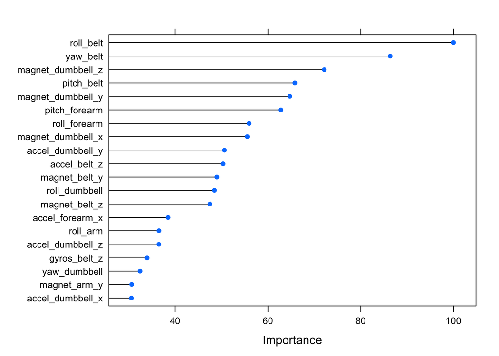

```r
plot(varImp(RFModel, scale = TRUE), top = 20)
```